# Cost-Effectiveness of Direct-Acting Antiviral Treatment Versus Peginterferon-Ribavirin for Genotype 1 Hepatitis C in the UK

Author

Chung Au-Yeung

Published

May 26, 2026

## 1 Introduction

In United Kingdom, an estimated 110 thousand people are infected with hepatitis C virus (HCV) and 90% of the chronically infected people are genotype 1 [1,2]. In addition, the prevalence of HCV infection in men is found to be disproportionally higher than women in Europe (Baden, 2014). HCV infection is the cause of cirrhosis, liver failure and liver-related death, but in a comparatively slow progressing rate. Treatments are aided to prevent advanced liver damage and liver cancer development. Previously, one of the standard treatments of HCV genotype 1 is the combination therapy of peginterferon plus ribavirin (PR) that requires a 48 weeks course of treatment [3]. The introduction of direct-acting antiviral (DAA) has shortened the duration of the treatment to 12 weeks and sustained virological response (SVR) are achieved in more than 95 % of the patients [4]. However, the benefits of DAA treatment come with a huge cost, imposing a cost ranging from £30000 to £60000 per patient.

The aim of this study is to estimate the cost-effectiveness of DAA treatment against the previously recommended PR treatment of HCV male patients with genotype 1 from a National Health services (NHS) perspective.

## 2 Method

### 2.1 Overview

A Markov model was used to evaluate the cost-effectiveness of DAA treatment of genotype 1 male patients, compared to the usual practice of peginterferon treatment from the NHS perspective in the UK. The costs and the effects of the DAA treatment versus the PR treatment were calculated for a cohort of 397 patients that were diagnosed with different liver fibrosis stages [5] and were expressed in terms of ICER. The cohort of patients were generated from five centres across the Trent region with age over 40. This report assumed that the mean age of the HCV patients was 45-year-old and the cohort was genotype 1. Patients were retreated until they entered SVR states.

### 2.2 Model structure

The Markov model was designed according to the natural history of chronic hepatitis C, as presented in Figure 1. The model was simulated annually for a time horizon of 30 years, estimating the long-term effect of the treatment and representing the chronic nature of hepatitis C. It included 11 health states, mild HCV, moderate HCV, compensated cirrhosis (CC), decompensated cirrhosis (DC), Hepatocellular carcinoma (HCC), Liver Transplant (LT), post-liver transplant (PLT), SVR from mild HCV, moderate HCV and CC (SVRmi, SVRmo, SVRcc) and liver-related death (LRD). Patients from DC, HCC, LT, PLT were assumed to face mortality risk in LRD, whereas the patients in the remaining health states were exposed to age and sex-specific probabilities of all-causes death.

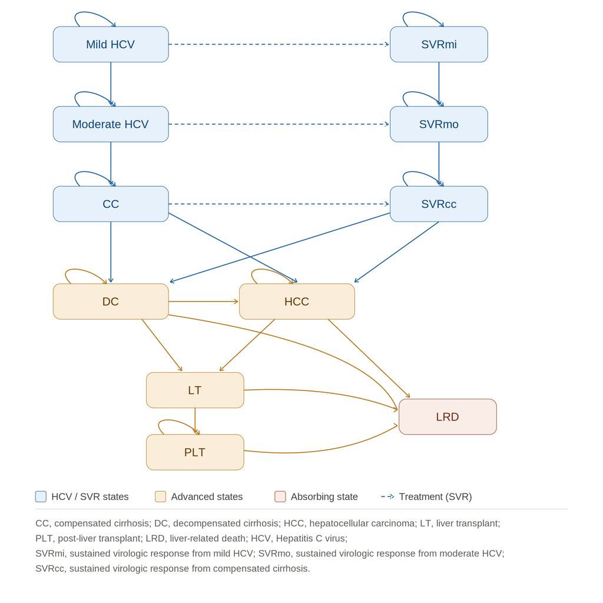

Figure 1: Natural history Markov model for chronic hepatitis C

### 2.3 Transition Probabilities

Meta-analysis of Histological Data in Viral Hepatitis (**METAVIR)** scoring system was employed to reflect the progression of liver fibrosis stage (F0-F2 are defined as mild HCV; F3 is defined as moderate HCV; F4 is defined as compensated cirrhosis). Transition probabilities between various stages of disease progression were based on systematic review and published economic evaluations [6–8] in Table 1**.** Patients can remain in their current health state or progress to the next worse health state except the LT health state which forced patient to move to PLT or LRD health states in the subsequent cycle. The progression of the disease can be stopped by the treatment. Patients who achieved SVR mild and SVR moderate from mild HCV and moderate HCV were assumed to be fully cured and liver damage is reversed. In addition, even if patients from CC had successful treatment, they had the chance to experience regression of liver fibrosis and develop to advanced liver damage (move from SVRcc to DC). The age and sex-specific probabilities of all-causes death were derived from the latest published national life table by the Office of National Statistics in the UK in 2020.

### 2.4 Treatment efficacy

Treatment efficacy was measured by sustained virological response (SVR) which means that the RNA of HCV virus was not detected in the patient’s blood stream after 12 weeks of treatment. For patients with mild and moderate HCV, the SVR rate of the PR treatment is 60% and 51% respectively and 78% with DAA treatment for both health states. The SVR rate for patients with CC who received PR treatment is 33% and 56% for those who received DAA treatment (the rates above were not expressed in terms of annual probability). SVR rates were collected specifically for genotype 1 patients from clinical trial and meta-analysis [4,9]. The efficacy parameters of DAA and PR treatments were converted to annual probability of reaching SVR per annual cycle and were given in table 1.

### 2.5 Costs

Costs applied to this study were derived from 2 stages. Intervention cost and health states cost were estimated separately. For model simplicity, this study only included the drug costs of the DAA treatment and PR treatment, leaving the indirect medical costs (costs of monitoring, additional management etc.) excluded. The total drug costs of PR treatment were calculated for 48 weeks of combination therapy (peginterferon alfa-2a 180 µg/0.5 ml per week plus ribavirin 1000-1200mg per day) is £16543. Regarding to DAA treatment, a dosage of Sofosbuvir 400mg and 1000mg ribavirin per day comprised to the total drug costs of £39636 for a 12 weeks course of treatment [10].

Health State costs were taken from the observational study conducted during the UK mild HCV trial in 2005. For the costs of liver transplant and post-liver transplant, data were extracted from a programme funded by Department of Health in 2001 (table 1). This study assumed that there were costs incurred even if patients were fully cured and achieved SVR health states.

Intervention costs and Health states costs were reported in 2002/03 GBP and 2015 GBP in the literatures and this study adjusted the costs through Consumer Price Index (CPI) to 2020 GBP. Future costs were discounted at a rate of 3.5% in regards to the current NICE guideline

### 2.6 Health States Utilities

The health state utilities were expressed in terms of Quality-adjusted life years (QALYs). These health outcomes were extracted from the UK Mild HCV trial in 2005. Patients were given SF-36 questionnaire during treatment and follow-up. To be in line with the current NICE guidance, a discount rate of 3.5% was applied to future health outcomes.

Table 1

**Table 1. Model parameters for transition rates, treatment efficacy, health utilities and health-state costs**

|  | From / health state | To | Mean | Distribution | Source |
| --- | --- | --- | --- | --- | --- |
| Transition probabilities |  |  |  |  |  |
|  | Mild HCV | Moderate HCV | 0.0250 | Beta (α = 38.0609, β = 1484.3765) | Grieve (2006) |
|  | Moderate HCV | Compensated cirrhosis | 0.0370 | Beta (α = 26.8680, β = 699.2952) | Grieve (2006) |
|  | Compensated cirrhosis | Decompensated cirrhosis | 0.0390 | Beta (α = 14.5778, β = 359.2122) | Grieve (2006) |
|  | Compensated cirrhosis | Hepatocellular carcinoma | 0.0140 | Beta (α = 1.9186, β = 135.1214) | Grieve (2006) |
|  | SVR after cirrhosis | Decompensated cirrhosis | 0.0030 | Beta (α = 1976.5905, β = 589816.9695) | Coffin (2012) |
|  | Decompensated cirrhosis | Hepatocellular carcinoma | 0.0140 | Beta (α = 1.9816, β = 135.1214) | Grieve (2006) |
|  | Decompensated cirrhosis | Liver transplant | 0.0300 | Beta (α = 6.5256, β = 210.9945) | Shepard (2001) |
|  | Decompensated cirrhosis | Liver-related death | 0.1300 | Beta (α = 146.9000, β = 983.1000) | Grieve (2006) |
|  | Hepatocellular carcinoma | Liver transplant | 0.0000 | N/A | Grieve (2006) |
|  | Hepatocellular carcinoma | Liver-related death | 0.4300 | Beta (α = 116.6733, β = 154.6600) | Grieve (2006) |
|  | Liver transplant | Liver-related death | 0.2100 | Beta (α = 16.2762, β = 61.2294) | Shepard (2001) |
|  | Liver transplant | Post-liver transplant | 0.7900 | N/A | Shepard (2001) |
|  | Post-liver transplant | Liver-related death | 0.0570 | Beta (α = 22.9017, β = 378.8825) | Shepard (2001) |
| Treatment efficacy (in probability) |  |  |  |  |  |
| DAA Treatment | Mild HCV | SVR mild | 0.9985 | Beta (α = 7, β = 2) | WHO (2016) |
| DAA Treatment | Moderate HCV | SVR moderate | 0.9985 | Beta (α = 7, β = 2) | WHO (2016) |
| DAA Treatment | Compensated cirrhosis | SVR cirrhosis | 0.9704 | Beta (α = 15, β = 12) | WHO (2016) |
| PR Treatment | Mild HCV | SVR mild | 0.4800 | Beta (α = 145, β = 97) | Bruno (2010) |
| PR Treatment | Moderate HCV | SVR moderate | 0.4000 | Beta (α = 32, β = 31) | Bruno (2010) |
| PR Treatment | Compensated cirrhosis | SVR cirrhosis | 0.2500 | Beta (α = 11, β = 25) | Bruno (2010) |
| Health States Utilities |  |  |  |  |  |
|  | Mild HCV | — | 0.7700 | Beta (α = 521.2375, β = 155.6943) | Grieve (2006) |
|  | Moderate HCV | — | 0.6600 | Beta (α = 115.7060, β = 59.6063) | Grieve (2006) |
|  | Compensated cirrhosis | — | 0.5500 | Beta (α = 47.1021, β = 38.5381) | Grieve (2006) |
|  | Decompensated cirrhosis | — | 0.4500 | Beta (α = 123.7500, β = 151.2500) | Grieve (2006) |
|  | Hepatocellular carcinoma | — | 0.4500 | Beta (α = 123.7500, β = 151.2500) | Grieve (2006) |
|  | Liver transplant | — | 0.4500 | Beta (α = 123.7500, β = 151.2500) | Grieve (2006) |
|  | Post-liver transplant | — | 0.6700 | Beta (α = 59.2548, β = 29.1825) | Martin (2016) |
|  | SVR mild | — | 0.8200 | Beta (α = 65.8678, β = 14.4588) | Martin (2016) |
|  | SVR moderate | — | 0.7200 | Beta (α = 58.0608, β = 22.5792) | Martin (2016) |
|  | SVR cirrhosis | — | 0.6100 | Beta (α = 58.0476, β = 37.1124) | Martin (2016) |
| Health States Costs (Adjusted) in £ |  |  |  |  |  |
|  | Mild HCV | — | £ 201 | CPI × Gamma (α = 25.6995, β = 5.3698) | Wright (2005) |
|  | Moderate HCV | — | £ 1,046 | CPI × Gamma (α = 88.8502, β = 8.0698) | Wright (2005) |
|  | Compensated cirrhosis | — | £ 1,660 | CPI × Gamma (α = 24.2342, β = 46.9584) | Wright (2005) |
|  | Decompensated cirrhosis | — | £13,306 | CPI × Gamma (α = 36.0249, β = 253.1582) | Wright (2005) |
|  | Hepatocellular carcinoma | — | £11,857 | CPI × Gamma (α = 18.1081, β = 448.8045) | Wright (2005) |
|  | Liver transplant | — | £39,876 | CPI × Gamma (α = 89.7536, β = 304.5004) | Longworth (2001) |
|  | Liver transplant care | — | £13,799 | CPI × Gamma (α = 13.7788, β = 686.4168) | Longworth (2001) |
|  | Post-liver transplant | — | £ 2,020 | CPI × Gamma (α = 15.2189, β = 91.0053) | Longworth (2001) |
|  | SVR mild/moderate/cirrhosis | — | £ 377 | CPI × Gamma (α = 28.8141, β = 8.9887) | Wright (2005) |

*LTC = liver transplant care. The cost of liver transplant care is added to the liver transplant state in the model.*

### 2.7 Sensitivity Analysis

This study conducted a probabilistic sensitivity analysis (PSA) to test the robustness of the model through accessing parameters uncertainty. Transition probabilities, treatment efficacy and health states utilities were fitted by beta distribution whereas costs were fitted by gamma distribution. The parameters of drugs costs were not varied in PSA due to limited data. Moreover, 1000 iterations of Monte Carlo simulations were performed in order to build up the Cost-effectiveness acceptability curve (CEAC).

## 3 Results

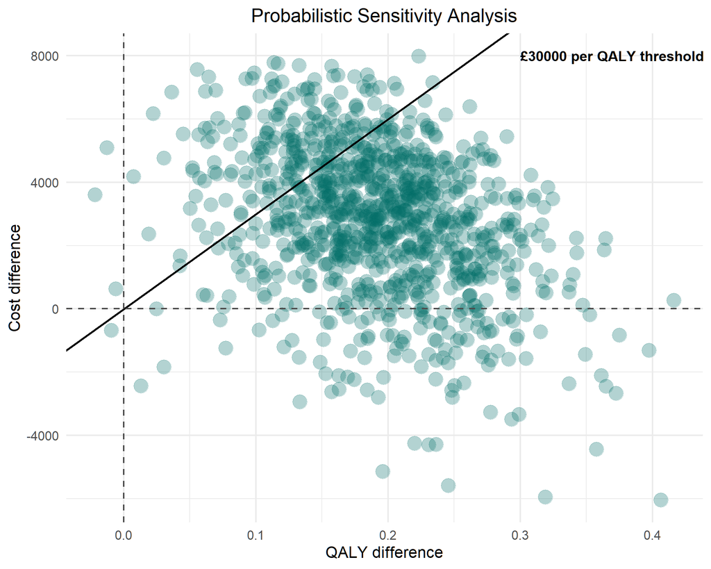

Figure 2: Probabilistic sensitivity analysis cost-effectiveness plane

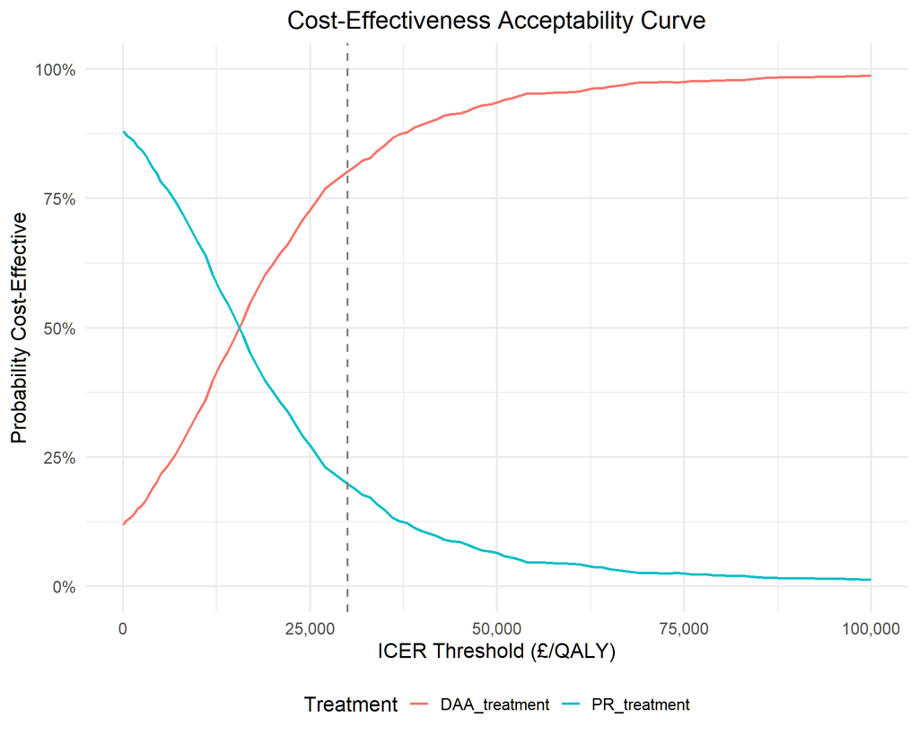

Figure 3: Cost-Effectiveness Acceptability Curve

## 4 Discussion

The fibrosis stage distribution of the patient cohort is crucial in determining the cost-effectiveness of DAA treatment from the UK NHS perspective. Based on the author’s knowledge, there are limited existing studies that evaluated patients at the more advanced fibrosis stage [11,12]. Allowing patients with fibrosis F4 to be entered the model at the very beginning is a strength in reflecting the realistic situation. It also suggested that greater benefits could be generated if sicker patients were prioritized to be treated with DAA regimen.

This study has several limitations. First, there is a statistical issue in the model due to insufficient data provided from the literature. This model used standard deviation for calculating the beta distribution for the transition probability from SVRcc to DC. As a consequence, the uncertainty of this parameter within the group might not have accessed. However, the parameter is not as important as others, therefore, it is unlikely that it will cause detrimental effect to the results. Second, this study assumed that patients were retreated until they achieved SVR, but in reality, there are strict criteria in allowing for retreatment after a failure in achieving SVR. Therefore, overestimating the benefits of DAA treatment. Third, the model was highly dependent on the patient cohort. The patient cohort this study employed was back in 2001 because the more updated available cohort was unable to obtain (a submission is needed to access data from HCV Research UK TDAC). Thereby, facing the risk of either underestimating or overestimating the benefits of DAA treatment. Fourth, treatment duration of DAA was relatively shorter than PR treatment, treatment efficacy was forcefully adjusted annually to transition probabilities, the model might have overestimated the benefits of DAA and underestimated the benefits of PR. However, the transition probabilities were not having much deviations with published economic evaluations [13–15].

There is a larger concern on whether these findings could be taken into consideration for clinical practice. [16] argue that mild chronic hepatitis C patients usually are at a lower risk in progression, unlikely to be affected by the disease due to minimal symptoms and have the luxury of waiting for treatment. Even if the study was in the context of interferon-based treatment, the argument seemed to be also true regarding to DAA treatment. The additional health benefits of DAA treatment for patients with early stage of fibrosis (F0-F2) might be minimal. It suggests that delaying DAA treatment until patients progress to cirrhosis (F4) could generate greater health benefits, therefore, more cost-effective. However, this strategy would be criticized of putting patients at risk in developing severe liver damage if they were not treated at the early stages.

In conclusion, this study demonstrated that DAA treatment is cost-effective in male HCV patients with genotype 1 from the NHS perspective. Investing in DAA treatment would be rewarding to the population health. However, this study adopted a simple strategy in prescribing patients at all stages at the beginning of the cycle. Further studies are needed to evaluate the strategies of prescribing DAA treatment whether at an early-stage or until patients are progressed to the advanced-stage.

## References

[1]

National Institute for Health and Care Excellence. [Technology appraisal guidance [TA363]: Ledipasvir-sofosbuvir for treating chronic hepatitis c](https://www.nice.org.uk/guidance/ta363). NICE; 2015.

[2]

Public Health England. [Hepatitis c in the UK 2020: Working to eliminate hepatitis c as a major public health threat](https://assets.publishing.service.gov.uk/government/uploads/system/uploads/attachment_data/file/943154/HCV_in_the_UK_2020.pdf). Public Health England; 2020.

[3]

National Institute for Health and Care Excellence. [Technology appraisal guidance [TA75]: Interferon alfa (pegylated and non-pegylated) and ribavirin for the treatment of chronic hepatitis c](https://www.nice.org.uk/guidance/ta75/resources/interferon-alfa-pegylated-and-nonpegylated-and-ribavirin-for-the-treatment-of-chronic-hepatitis-c-pdf-2294760198085). NICE; 2004.

[4]

World Health Organization. [Guidelines for the screening, care, and treatment of persons with chronic hepatitis c infection](https://www.who.int/hepatitis/publications/hepatitis-c-guidelines-2016/en/). World Health Organization; 2016.

[5]

Mohsen AH, Trent HCV Study Group. The epidemiology of hepatitis c in a UK health regional population of 5.12 million. British Medical Journal 2001;48:707–13.

[6]

Coffin PO, Scott JD, Golden MR, Sullivan SD. Cost-effectiveness and population outcomes of general population screening for hepatitis c. Clinical Infectious Diseases 2012;54:1259–71.

[7]

Grieve R, Roberts J, Wright M, Sweeting M, De Angelis D, Rosenberg W, et al. Cost-effectiveness of interferon alfa or peginterferon alfa with ribavirin for histological mild chronic hepatitis c. Gut 2006;55:1332–8.

[8]

Shepard J, Jones J, Hartwell D, Davidson P, Price A, Waugh N. Interferon alfa (pegylated and non-pegylated) and ribavirin for the treatment of mild chronic hepatitis c: A systematic review and economic evaluation. Health Technology Assessment 2007;11.

[9]

Bruno S, Shiffman ML, Roberts SK, Gane EJ, Messinger D, et al. Efficacy and safety of peginterferon alfa-2a (40KD) plus ribavirin in hepatitis c patients with advanced fibrosis and cirrhosis. AASLD 2010;51:388–97.

[10]

National Institute for Health and Care Excellence. [Technology appraisal guidance [TA330]: Sofosbuvir for treating chronic hepatitis c](https://www.nice.org.uk/guidance/ta330/chapter/2-The-technology). NICE; 2015.

[11]

Foster GR, Irving WL, Cheung MC, et al. Impact of direct acting antiviral therapy in patients with chronic hepatitis c and decompensated cirrhosis. Journal of Hepatology 2016;64:1224–31.

[12]

Kamp WM, Sellers CM, Stein S, Lim JK. Impact of direct acting antivirals on survival in patients with chronic hepatitis c and hepatocellular carcinoma. Scientific Reports 2019;9:17081.

[13]

Eijsink JFH, Al Khayat MNMT, Boersma C, et al. Cost-effectiveness of hepatitis c virus screening, and subsequent monitoring or treatment among pregnant women in the netherlands. The European Journal of Health Economics 2021;22:75–88.

[14]

Marcellusi A, Viti R, Damele F, Camma C, Taliani G, Mennini FS. Early treatment in HCV: Is it a cost-utility option from the italian perspective? Clinical Drug Investigation 2016;26:661–72.

[15]

Due OT, Thakkinstian A, Thavorncharoensap M, Sobhonslidsuk A, et al. Cost-utility analysis of direct-acting antivirals for treatment of chronic hepatitis c genotype 1 and 6 in vietnam. Value Health 2020;23:1180–90.

[16]

Davis GL, Beck JR, Farrell G, Poynard T. Prolonged treatment with interferon in patients with histological mild chronic hepatitis c: A decision analysis. Journal of Viral Hepatitis 1998;5:313–21.